# Chapter 6

## Conceptual

### Excercise 1a

Best subset selection approach has the smallest training RSS among all the three methods. Because with $k$ predictors, both forward stepwise and backward stepwise selection methods need to fix $j - 1$ predictors before finding the best $j$ -th predictor, thus the search space will be reduced comparing to best subset selection approach.

### Excercise 1b

Cannot be determined. Best subset selection approach has higher chance to achive smallest test RSS since it considers more models. However, it is still possible for forward stepwise and backward stepwise selection methods to outperform best subset selection method in terms of test RSS.

### Excercise 1c

1. TRUE.
2. TRUE.
3. FALSE.
4. FALSE.
5. FASLE.

### Excercise 2a

**iii** is correct: least squares has low bias when $p$ is sufficiently large. Since lasso constraints non-zero coefficient estimates to zeros, meaning an increase in bias (due to the reduced number of coefficient estimates) and a decrease in variance. If the decrease in variance is more than the increase in bias, lasso method will give improved prediction accuracy comparing to least squares method.

### Excercise 2b

**iii** is correct: same with above, except that ridge regression method supresses coefficient estimates to lower magnitude rather than setting them to zeros.

### Excercise 2c

**ii** is correct: non-linear methods are more flexible than least sqaures, resulting in reduced bias and increase in variance. If the decrease in bias is more than the increase in variance, we can expect an improved prediction accuracy in non-linear methods.

### Excercise 3a

**iv** is correct: when $s = 0$ (i.e., the $l_1$ norm constraint is strongest), the model supresses all coefficient estimates to zeros, resulting in a null model which consists of only intercept term. In this case, the training RSS is *largest* since no predictors helps explain the response. As $s$ increases, coefficient estimates become larger and response are better explained which leads to a *steadily decrease* in training RSS.

### Excercise 3b

**ii** is correct: as $s$ increases, $l_1$ norm constraint becomes weaker, resulting in more coefficient estimates with larger values. We can expect test RSS decreases first as the model explains more in response, however, when $s$ becomes sufficiently large, lasso is closing to the linear regression model and in this case, the increase in variance is more than the decrease in bias thus resulting in an increase in test RSS. Overall speaking, the test RSS can be drawn in a U-shape.

### Excercise 3c

**iii** is correct: as explained above, when $s$ increases from 0, the model develops from null model to linear regression model, where the variance is increasing.

### Excercise 3d

**iv** is correct: as explained above, when $s$ increases from 0, the model develops from null model to linear regression model, where the squared bias is decreasing.

### Excercise 3e

**v** is corerct: irreducible error won’t be changed and keeps constant no matter how $s$ changes (i.e. *model independent*).

### Excercise 4a

**iii** is correct: as $\lambda$ increases from 0, the model develops from linear regression method to a $l_2$ norm constrained one meaning that the training error is increasing.

### Excercise 4b

**ii** is correct: when $\lambda = 0$, ridge regression is equivalent to linear regression and as $\lambda$ increases, the decrease in bias is more than the increase in variance resulting in a decrease in test RSS. After certain point, test RSS increases when the decrease in bias is less than the increase in variance. Therefore, the test RSS can be drawn in a U-shape.

### Excercise 4c

**iv** is correct: as $\lambda$ increases from 0, the model develops from linear regression method to a more $l_2$ norm constrained one which leads to decreasing variance. On the other hand, suppose $\lambda = +\infty$, then ${\bf{\beta }} = {\bf 0}$, and the model becomes constant where the variance is smallest.

### Excercise 4d

**iii** is correct: as $\lambda$ increases from 0, the model develops from linear regression method to a more $l_2$ norm constrained one which leads to increasing squared bias. On the other hand, suppose $\lambda = +\infty$, then ${\bf{\beta }} = {\bf 0}$, and the model becomes constant where the squared bias is largest.

### Excercise 4e

**v** is correct: irreducible error is model independent.

### Excercise 5a

$\begin{array}{l} \sum\nolimits_{i = 1}^n {{{({y_i} - {{\hat \beta }_0} - \sum\nolimits_{j = 1}^p {{{\hat \beta }_j}{x_{ij}}} )}^2} + \lambda \sum\nolimits_{j = 1}^p {\hat \beta _j^2} } \\ = \sum\nolimits_{i = 1}^n {{{({y_i} - {{\hat \beta }_0} - {{\hat \beta }_1}{x_{i1}} - {{\hat \beta }_2}{x_{i2}})}^2} + \lambda \beta _1^2 + \lambda \hat \beta _2^2} \\ = {({y_1} - {{\hat \beta }_0} - {{\hat \beta }_1}{x_{11}} - {{\hat \beta }_2}{x_{12}})^2} + {({y_2} - {{\hat \beta }_0} - {{\hat \beta }_1}{x_{21}} - {{\hat \beta }_2}{x_{22}})^2} + \lambda \hat \beta _1^2 + \lambda \hat \beta _2^2 \end{array}$ Since $\begin{array}{l} {{\hat \beta }_0} = 0\\ {y_1} + {y_2} = 0\\ {x_{11}} + {x_{21}} = 0\\ {x_{12}} + {x_{22}} = 0 \end{array}$ , meaning that both predictors $x_1$, $x_2$ and response $y$ were centrally normalized which resulted in ${\hat \beta}_0 = 0$.

Therefore, the ridge regression optimization was rewritten as ${({y_1} - {{\hat \beta }_1}{x_{11}} - {{\hat \beta }_2}{x_{12}})^2} + {({y_2} - {{\hat \beta }_1}{x_{21}} - {{\hat \beta }_2}{x_{22}})^2} + \lambda \hat \beta _1^2 + \lambda \hat \beta _2^2$

### Excercise 5b

Take the derivatives w.r.t. $\hat \beta _1$ and $\hat \beta _2$ respectively and setting them to zeros, we have: $\begin{array}{l} \frac{d}{{d{{\hat \beta }_1}}}f(x) = - 2({x_{11}} + {x_{21}}) + 2\lambda {{\hat \beta }_1} = 0\\ \frac{d}{{d{{\hat \beta }_2}}}f(x) = - 2({x_{12}} + 2{x_{22}}) + 2\lambda {{\hat \beta }_2} = 0 \end{array}$ Therefore, $- 2({x_{11}} + {x_{21}}) + 2\lambda {{\hat \beta }_1} = - 2({x_{12}} + 2{x_{22}}) + 2\lambda {{\hat \beta }_2}$ Given ${x_{11}} + {x_{21}} = 0$ and ${x_{12}} + {x_{22}} = 0$, $\begin{array}{l} 2\lambda {{\hat \beta }_1} = 2\lambda {{\hat \beta }_2}\\ {{\hat \beta }_1} = {{\hat \beta }_2} \end{array}$

### Excercise 5c

$\begin{array}{l} \sum\nolimits_{i = 1}^n {{{({y_i} - {{\hat \beta }_0} - \sum\nolimits_{j = 1}^p {{{\hat \beta }_j}{x_{ij}}} )}^2} + \lambda \sum\nolimits_{j = 1}^p {\left| {{{\hat \beta }_j}} \right|} } \\ = \sum\nolimits_{i = 1}^n {{{({y_i} - {{\hat \beta }_0} - {{\hat \beta }_1}{x_{i1}} - {{\hat \beta }_2}{x_{i2}})}^2} + \lambda \left| {{{\hat \beta }_1}} \right| + \lambda \left| {{{\hat \beta }_2}} \right|} \\ = {({y_1} - {{\hat \beta }_0} - {{\hat \beta }_1}{x_{11}} - {{\hat \beta }_2}{x_{12}})^2} + {({y_2} - {{\hat \beta }_0} - {{\hat \beta }_1}{x_{21}} - {{\hat \beta }_2}{x_{22}})^2} + \lambda \left| {{{\hat \beta }_1}} \right| + \lambda \left| {{{\hat \beta }_2}} \right| \end{array}$ Provided ${\hat \beta}_0 = 0$, we can rewrite the lasso optimization problem by ${({y_1} - {{\hat \beta }_1}{x_{11}} - {{\hat \beta }_2}{x_{12}})^2} + {({y_2} - {{\hat \beta }_1}{x_{21}} - {{\hat \beta }_2}{x_{22}})^2} + \lambda \left| {{{\hat \beta }_1}} \right| + \lambda \left| {{{\hat \beta }_2}} \right|$

### Excercise 5d*([Sadoughi, 2015](https://github.com/asadoughi/stat-learning))

To take the derivatives of functions containing absolute values, we can utilize: $\frac{d}{{dx}}\left| {\rm{u}} \right| = \frac{d}{{dx}}\sqrt {{{\rm{u}}^2}} = \frac{d}{{dx}}{\left( {{{\rm{u}}^2}} \right)^{\frac{1}{2}}} = \frac{1}{2}{\left( {{{\rm{u}}^2}} \right)^{ - \frac{1}{2}}} \bullet 2{\rm{u}} \bullet {\rm{u' = }}\frac{{{\rm{u}} \bullet {\rm{u'}}}}{{\sqrt {{{\rm{u}}^2}} }}{\rm{ = }}\frac{{{\rm{u}} \bullet {\rm{u'}}}}{{\left| {\rm{u}} \right|}}$ Then by taking the derivatives w.r.t. $\hat \beta _1$ and $\hat \beta _2$ respectively and setting them to zeros, we have: $\begin{array}{l} \frac{d}{{d{{\hat \beta }_1}}}f(x) = - 2({x_{11}} + {x_{21}}) + \lambda \frac{{{{\hat \beta }_1}}}{{\left| {{{\hat \beta }_1}} \right|}} = 0\\ \frac{d}{{d{{\hat \beta }_2}}}f(x) = - 2({x_{12}} + 2{x_{22}}) + \lambda \frac{{{{\hat \beta }_2}}}{{\left| {{{\hat \beta }_2}} \right|}} = 0 \end{array}$ Therefore, $- 2({x_{11}} + {x_{21}}) + \lambda \frac{{{{\hat \beta }_1}}}{{\left| {{{\hat \beta }_1}} \right|}} = - 2({x_{12}} + 2{x_{22}}) + \lambda \frac{{{{\hat \beta }_2}}}{{\left| {{{\hat \beta }_2}} \right|}}$ Given ${x_{11}} + {x_{21}} = 0$ and ${x_{12}} + {x_{22}} = 0$, $\frac{{{{\hat \beta }_1}}}{{\left| {{{\hat \beta }_1}} \right|}} = \frac{{{{\hat \beta }_2}}}{{\left| {{{\hat \beta }_2}} \right|}}$ , from which we can see there are many possible solutions and $\hat{\beta}_1$, $\hat{\beta}_2$ take the same sign. Consider the alternative form of lasso constraints $| \hat{\beta}_1 | + | \hat{\beta}_2 | < s$, we have solutions $| \hat{\beta}_1 | + | \hat{\beta}_2 | = s$, which can be furthur expanded to:  
$\hat{\beta}_1 + \hat{\beta}_2 = s; \hat{\beta}_1 \geq 0; \hat{\beta}_2 \geq 0$ and $\hat{\beta}_1 + \hat{\beta}_2 = -s; \hat{\beta}_1 \leq 0; \hat{\beta}_2 \leq 0$.

We can also explain the solutions from a geometric interpretation:  
Provided the facts that $x_{11} = x_{12}$, $x_{21} = x_{22}$ and $y_1 + y_2 = 0$, we can simplify the lasso optimization as $2\times (y_1 - (\hat{\beta}_1 + \hat{\beta}_2)x_{11})^2$ This optimization problem has a simple solution: $\hat{\beta}_1 + \hat{\beta}_2 = \frac{y_1}{x_{11}}$. This is a line parallel to the edge of lasso-diamond $\hat{\beta}_1 + \hat{\beta}_2 = s$. As a result, the entire edge $\hat{\beta}_1 + \hat{\beta}_2 = s$ is a potential solution to the Lasso optimization problem!

Similar argument can be made for the opposite Lasso-diamond edge: $\hat{\beta}_1 + \hat{\beta}_2 = -s$.

Finally, the general form of solution is given by two line segments:  
$\hat{\beta}_1 + \hat{\beta}_2 = s; \hat{\beta}_1 \geq 0; \hat{\beta}_2 \geq 0$ and $\hat{\beta}_1 + \hat{\beta}_2 = -s; \hat{\beta}_1 \leq 0; \hat{\beta}_2 \leq 0$.

### Excercise 6a

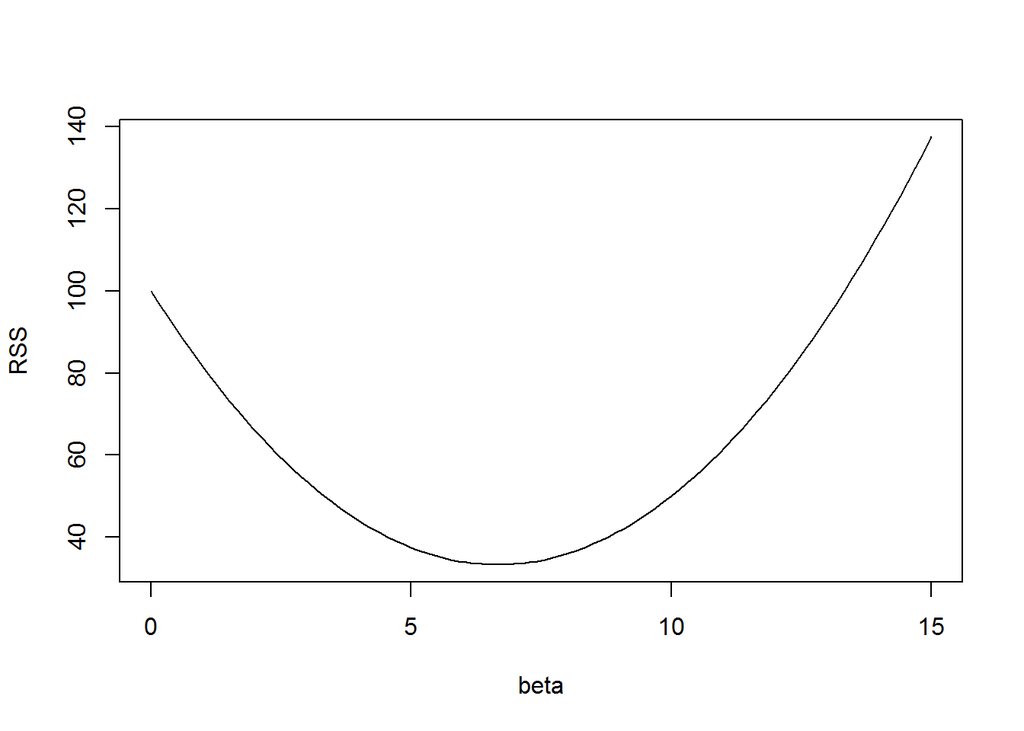

```r
y = 10; lambda = 0.5
beta = seq(0, 15, length = 100)
RSS = (y - beta)^2 + lambda * (beta^2)
plot(beta, RSS, type = "l")
```

```r
beta[which.min(RSS)]
```

```
## [1] 6.666667
```

```r
best_beta = y / (1 + lambda)
best_beta
```

```
## [1] 6.666667
```

As shown above, (6.12) can be solved directly by (6.14).

**Proof**:  
When there is only one predictor, we take the simple form of ridge regression as ${({y_1} - {{\hat \beta }_1})^2} + \lambda \hat \beta _1^2$ Take derivative w.r.t. ${\hat \beta _1}$, then we have: $\begin{array}{l} - 2({y_1} - {{\hat \beta }_1}) + 2\lambda {{\hat \beta }_1} = 0\\ - {y_1} + {{\hat \beta }_1} + \lambda {{\hat \beta }_1} = 0\\ {{\hat \beta }_1} = \frac{{{y_1}}}{{1 + \lambda }} \end{array}$ , which confirms with Equation (6.14).

### Excercise 6b

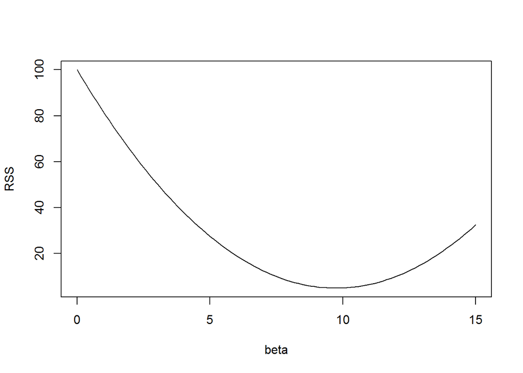

```r
y = 10; lambda = 0.5
beta = seq(0, 15, length = 100)
RSS = (y - beta)^2 + lambda * abs(beta)
plot(beta, RSS, type = "l")
```

```r
beta[which.min(RSS)]
```

```
## [1] 9.69697
```

```r
if (y > lambda / 2) {
  best_beta = y - lambda / 2
} else if (y < -lambda / 2) {
  best_beta = y + lambda / 2
} else {
  best_beta = 0
}
best_beta
```

```
## [1] 9.75
```

As shown above, (6.13) can be solved directly by (6.15). It is noteworthy that the discrepancy between two beta values resulted from sampling error of betas.

### Excercise 7a*([Sadoughi, 2015](https://github.com/asadoughi/stat-learning))

The likelihood for the data is:

$\begin{aligned} L(\theta \mid \beta) &= p(\beta \mid \theta) \\ &= p(\beta_1 \mid \theta) \times \cdots \times p(\beta_n \mid \theta) \\ &= \prod_{i = 1}^{n} p(\beta_i \mid \theta) \\ &= \prod_{i = 1}^{n} \frac{ 1 }{ \sigma \sqrt{2\pi} } \exp \left(- \frac{ Y_i - (\beta_0 + \sum_{j = 1}^{p} \beta_j X_{ij}) }{ 2\sigma^2 } \right) \\ &= \left( \frac{ 1 }{ \sigma \sqrt{2\pi} } \right)^n \exp \left( - \frac{ 1 }{ 2\sigma^2 } \sum_{i = 1}^{n} \left[ Y_i - (\beta_0 + \sum_{j = 1}^{p} \beta_j X_{ij}) \right]^2 \right) \end{aligned}$

### Excercise 7b*([Sadoughi, 2015](https://github.com/asadoughi/stat-learning))

The posterior with double exponential (Laplace Distribution) with mean 0 and common scale parameter $b$, i.e. $p(\beta) = \frac{1}{2b}\exp(- \lvert \beta \rvert / b)$ is:

$f(\beta \mid X, Y) \propto f(Y \mid X, \beta) p(\beta \mid X) = f(Y \mid X, \beta) p(\beta)$

Substituting our values from (a) and our density function gives us:

$\begin{aligned} f(Y \mid X, \beta)p(\beta) &= \left( \frac{ 1 }{ \sigma \sqrt{2\pi} } \right)^n \exp \left( - \frac{ 1 }{ 2\sigma^2 } \sum_{i = 1}^{n} \left[ Y_i - (\beta_0 + \sum_{j = 1}^{p} \beta_j X_{ij}) \right]^2 \right) \left( \frac{ 1 }{ 2b } \exp(- \lvert \beta \rvert / b) \right) \\ &= \left( \frac{ 1 }{ \sigma \sqrt{2\pi} } \right)^n \left( \frac{ 1 }{ 2b } \right) \exp \left( - \frac{ 1 }{ 2\sigma^2 } \sum_{i = 1}^{n} \left[ Y_i - (\beta_0 + \sum_{j = 1}^{p} \beta_j X_{ij}) \right]^2 - \frac{ \lvert \beta \rvert }{ b } \right) \end{aligned}$

### Excercise 7c*([Sadoughi, 2015](https://github.com/asadoughi/stat-learning))

Showing that the Lasso estimate for $\beta$ is the mode under this posterior distribution is the same thing as showing that the most likely value for $\beta$ is given by the lasso solution with a certain $\lambda$.

We can do this by taking our likelihood and posterior and showing that it can be reduced to the canonical Lasso Equation 6.7 from the book.

Let’s start by simplifying it by taking the logarithm of both sides:

$\begin{aligned} \log f(Y \mid X, \beta)p(\beta) &= \log \left[ \left( \frac{ 1 }{ \sigma \sqrt{2\pi} } \right)^n \left( \frac{ 1 }{ 2b } \right) \exp \left( - \frac{ 1 }{ 2\sigma^2 } \sum_{i = 1}^{n} \left[ Y_i - (\beta_0 + \sum_{j = 1}^{p} \beta_j X_{ij}) \right]^2 - \frac{ \lvert \beta \rvert }{ b } \right) \right] \\ &= \log \left[ \left( \frac{ 1 }{ \sigma \sqrt{2\pi} } \right)^n \left( \frac{ 1 }{ 2b } \right) \right] - \left( \frac{ 1 }{ 2\sigma^2 } \sum_{i = 1}^{n} \left[ Y_i - (\beta_0 + \sum_{j = 1}^{p} \beta_j X_{ij}) \right]^2 + \frac{ \lvert \beta \rvert }{ b } \right) \end{aligned}$

We want to maximize the posterior, this means: $\begin{aligned} \arg\max_\beta \, f(\beta \mid X, Y) &= \arg\max_\beta \, \log \left[ \left( \frac{ 1 }{ \sigma \sqrt{2\pi} } \right)^n \left( \frac{ 1 }{ 2b } \right) \right] - \left( \frac{ 1 }{ 2\sigma^2 } \sum_{i = 1}^{n} \left[ Y_i - (\beta_0 + \sum_{j = 1}^{p} \beta_j X_{ij}) \right]^2 + \frac{ \lvert \beta \rvert }{ b } \right) \\ \end{aligned}$

Since we are taking the difference of two values, the maximum of this value is the equivalent to taking the difference of the second value in terms of $\beta$. This results in:

$\begin{aligned} &= \arg\min_\beta \, \frac{ 1 }{ 2\sigma^2 } \sum_{i = 1}^{n} \left[ Y_i - (\beta_0 + \sum_{j = 1}^{p} \beta_j X_{ij}) \right]^2 + \frac{ \lvert \beta \rvert }{ b } \\ &= \arg\min_\beta \, \frac{ 1 }{ 2\sigma^2 } \sum_{i = 1}^{n} \left[ Y_i - (\beta_0 + \sum_{j = 1}^{p} \beta_j X_{ij}) \right]^2 + \frac{ 1 }{ b } \sum_{j = 1}^{p} \lvert \beta_j \rvert \\ &= \arg\min_\beta \, \frac{ 1 }{ 2\sigma^2 } \left( \sum_{i = 1}^{n} \left[ Y_i - (\beta_0 + \sum_{j = 1}^{p} \beta_j X_{ij}) \right]^2 + \frac{ 2\sigma^2 }{ b } \sum_{j = 1}^{p} \lvert \beta_j \rvert \right) \end{aligned}$

By letting $\lambda = 2\sigma^2/b$, we can see that we end up with:

$\begin{aligned} &= \arg\min_\beta \, \sum_{i = 1}^{n} \left[ Y_i - (\beta_0 + \sum_{j = 1}^{p} \beta_j X_{ij}) \right]^2 + \lambda \sum_{j = 1}^{p} \lvert \beta_j \rvert \\ &= \arg\min_\beta \, \text{RSS} + \lambda \sum_{j = 1}^{p} \lvert \beta_j \rvert \end{aligned}$

which we know is the Lasso from Equation 6.7 in the book. Thus we know that when the posterior comes from a Laplace distribution with mean zero and common scale parameter $b$, the mode for $\beta$ is given by the Lasso solution when $\lambda = 2\sigma^2 / b$.

### Excercise 7d*([Sadoughi, 2015](https://github.com/asadoughi/stat-learning))

The posterior distributed according to Normal distribution with mean 0 and variance $c$ is:

$\begin{aligned} f(\beta \mid X, Y) \propto f(Y \mid X, \beta) p(\beta \mid X) = f(Y \mid X, \beta) p(\beta) \end{aligned}$

Our probability distribution function then becomes: $p(\beta) = \prod_{i = 1}^{p} p(\beta_i) = \prod_{i = 1}^{p} \frac{ 1 }{ \sqrt{ 2c\pi } } \exp \left( - \frac{ \beta_i^2 }{ 2c } \right) = \left( \frac{ 1 }{ \sqrt{ 2c\pi } } \right)^p \exp \left( - \frac{ 1 }{ 2c } \sum_{i = 1}^{p} \beta_i^2 \right)$

Substituting our values from (a) and our density function gives us:

$\begin{aligned} f(Y \mid X, \beta)p(\beta) &= \left( \frac{ 1 }{ \sigma \sqrt{2\pi} } \right)^n \exp \left( - \frac{ 1 }{ 2\sigma^2 } \sum_{i = 1}^{n} \left[ Y_i - (\beta_0 + \sum_{j = 1}^{p} \beta_j X_{ij}) \right]^2 \right) \left( \frac{ 1 }{ \sqrt{ 2c\pi } } \right)^p \exp \left( - \frac{ 1 }{ 2c } \sum_{i = 1}^{p} \beta_i^2 \right) \\ &= \left( \frac{ 1 }{ \sigma \sqrt{2\pi} } \right)^n \left( \frac{ 1 }{ \sqrt{ 2c\pi } } \right)^p \exp \left( - \frac{ 1 }{ 2\sigma^2 } \sum_{i = 1}^{n} \left[ Y_i - (\beta_0 + \sum_{j = 1}^{p} \beta_j X_{ij}) \right]^2 - \frac{ 1 }{ 2c } \sum_{i = 1}^{p} \beta_i^2 \right) \end{aligned}$

### Excercise 7e*([Sadoughi, 2015](https://github.com/asadoughi/stat-learning))

Like from part c, showing that the Ridge Regression estimate for $\beta$ is the mode and mean under this posterior distribution is the same thing as showing that the most likely value for $\beta$ is given by the lasso solution with a certain $\lambda$.

We can do this by taking our likelihood and posterior and showing that it can be reduced to the canonical Ridge Regression Equation 6.5 from the book.

Let’s start by simplifying it by taking the logarithm of both sides:

Once again, we can take the logarithm of both sides to simplify it:

$\begin{aligned} \log f(Y \mid X, \beta)p(\beta) &= \left( \frac{ 1 }{ \sigma \sqrt{2\pi} } \right)^n \left( \frac{ 1 }{ \sqrt{ 2c\pi } } \right)^p \exp \left( - \frac{ 1 }{ 2\sigma^2 } \sum_{i = 1}^{n} \left[ Y_i - (\beta_0 + \sum_{j = 1}^{p} \beta_j X_{ij}) \right]^2 - \frac{ 1 }{ 2c } \sum_{i = 1}^{p} \beta_i^2 \right) \\ &= \log \left[ \left( \frac{ 1 }{ \sigma \sqrt{2\pi} } \right)^n \left( \frac{ 1 }{ \sqrt{ 2c\pi } } \right)^p \right] - \left( \frac{ 1 }{ 2\sigma^2 } \sum_{i = 1}^{n} \left[ Y_i - (\beta_0 + \sum_{j = 1}^{p} \beta_j X_{ij}) \right]^2 + \frac{ 1 }{ 2c } \sum_{i = 1}^{p} \beta_i^2 \right) \end{aligned}$

We want to maximize the posterior, this means: $\begin{aligned} \arg\max_\beta \, f(\beta \mid X, Y) &= \arg\max_\beta \, \log \left[ \left( \frac{ 1 }{ \sigma \sqrt{2\pi} } \right)^n \left( \frac{ 1 }{ \sqrt{ 2c\pi } } \right)^p \right] - \left( \frac{ 1 }{ 2\sigma^2 } \sum_{i = 1}^{n} \left[ Y_i - (\beta_0 + \sum_{j = 1}^{p} \beta_j X_{ij}) \right]^2 + \frac{ 1 }{ 2c } \sum_{i = 1}^{p} \beta_i^2 \right) \end{aligned}$

Since we are taking the difference of two values, the maximum of this value is the equivalent to taking the difference of the second value in terms of $\beta$. This results in:

$\begin{aligned} &= \arg\min_\beta \, \left( \frac{ 1 }{ 2\sigma^2 } \sum_{i = 1}^{n} \left[ Y_i - (\beta_0 + \sum_{j = 1}^{p} \beta_j X_{ij}) \right]^2 + \frac{ 1 }{ 2c } \sum_{i = 1}^{p} \beta_i^2 \right) \\ &= \arg\min_\beta \, \left( \frac{ 1 }{ 2\sigma^2 } \right) \left( \sum_{i = 1}^{n} \left[ Y_i - (\beta_0 + \sum_{j = 1}^{p} \beta_j X_{ij}) \right]^2 + \frac{ \sigma^2 }{ c } \sum_{i = 1}^{p} \beta_i^2 \right) \end{aligned}$

By letting $\lambda = \sigma^2/ c$, we end up with:

$\begin{aligned} &= \arg\min_\beta \, \left( \frac{ 1 }{ 2\sigma^2 } \right) \left( \sum_{i = 1}^{n} \left[ Y_i - (\beta_0 + \sum_{j = 1}^{p} \beta_j X_{ij}) \right]^2 + \lambda \sum_{i = 1}^{p} \beta_i^2 \right) \\ &= \arg\min_\beta \, \text{RSS} + \lambda \sum_{i = 1}^{p} \beta_i^2 \end{aligned}$

which we know is the Ridge Regression from Equation 6.5 in the book. Thus we know that when the posterior comes from a normal distribution with mean zero and variance $c$, the mode for $\beta$ is given by the Ridge Regression solution when $\lambda = \sigma^2 / c$. Since the posterior is Gaussian, we also know that it is the posterior mean.

## Applied

### Excercise 8a

```r
x = rnorm(100)
sigma = rnorm(100)
```

### Excercise 8b

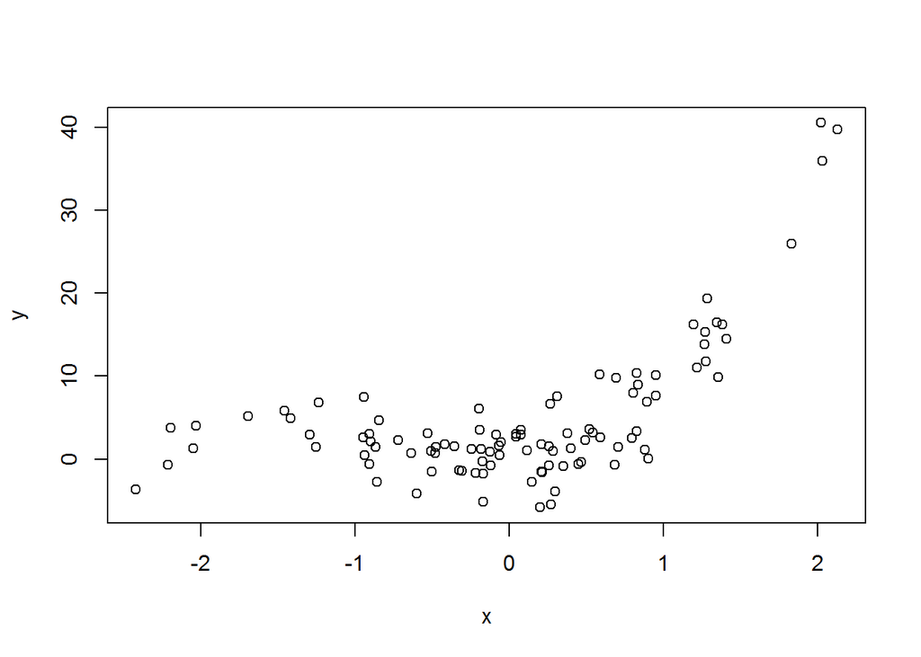

```r
beta_0 = 1; beta_1 = 0.5; beta_2 = 4.3; beta_3 = 1.8;
y = beta_0 +  beta_1 * x + beta_2 * x^2 + beta_3 * x^3 + 3*sigma
plot(x, y)
```

### Excercise 8c

```r
library(leaps)
regfit.full = regsubsets(y~., data = data.frame(poly(x, 10), y), nvmax = 10)
reg.summary = summary(regfit.full)
par(mfrow = c(2,2))
plot(reg.summary$rss, xlab = "Number of Variables", ylab = "RSS", type = "l")
points(which.min(reg.summary$rss), min(reg.summary$rss), col = "red", cex = 2, pch = 20)
plot(reg.summary$adjr2, xlab = "Number of variables", ylab = "Adjusted RSq", type = "l")
points(which.max(reg.summary$adjr2), max(reg.summary$adjr2), col = "red", cex = 2, pch = 20)
plot(reg.summary$cp, xlab = "Number of variables", ylab = "Mallows' Cp", type = "l")
points(which.min(reg.summary$cp), min(reg.summary$cp), col = "red", cex = 2, pch = 20)
plot(reg.summary$bic, xlab = "Number of variables", ylab = "BIC", type = "l")
points(which.min(reg.summary$bic), min(reg.summary$bic), col = "red", cex = 2, pch = 20)
```

[output not shown]

```r
# use built-in plot function
par(mfrow = c(1,1))
plot(regfit.full, scale = "adjr2")
```

[output not shown]

```r
plot(regfit.full, scale = "Cp")
```

[output not shown]

```r
plot(regfit.full, scale = "bic")
```

[output not shown]

```r
coef(regfit.full, 3)
```

```
## (Intercept)          X1          X2          X3
##    4.557712   48.111120   50.896815   29.886808
```

### Excercise 8d

```r
library(leaps)
regfit.fwd = regsubsets(y~., data = data.frame(poly(x, 10), y), nvmax = 10, method = "forward")
regfit.fwd_summary = summary(regfit.fwd)

regfit.bwd = regsubsets(y~., data = data.frame(poly(x, 10), y), nvmax = 10, method = "backward")
regfit.bwd_summary = summary(regfit.bwd)

par(mfrow = c(2,2))
plot(regfit.fwd_summary$rss, xlab = "Number of Variables", ylab = "RSS", type = "l")
points(which.min(regfit.fwd_summary$rss), min(regfit.fwd_summary$rss), col = "red", cex = 2, pch = 20)
plot(regfit.fwd_summary$adjr2, xlab = "Number of variables", ylab = "Adjusted RSq", type = "l")
points(which.max(regfit.fwd_summary$adjr2), max(regfit.fwd_summary$adjr2), col = "red", cex = 2, pch = 20)
plot(regfit.fwd_summary$cp, xlab = "Number of variables", ylab = "Mallows' Cp", type = "l")
points(which.min(regfit.fwd_summary$cp), min(regfit.fwd_summary$cp), col = "red", cex = 2, pch = 20)
plot(regfit.fwd_summary$bic, xlab = "Number of variables", ylab = "BIC", type = "l")
points(which.min(regfit.fwd_summary$bic), min(regfit.fwd_summary$bic), col = "red", cex = 2, pch = 20)
```

[output not shown]

```r
par(mfrow = c(2,2))
plot(regfit.bwd_summary$rss, xlab = "Number of Variables", ylab = "RSS", type = "l")
points(which.min(regfit.bwd_summary$rss), min(regfit.bwd_summary$rss), col = "red", cex = 2, pch = 20)
plot(regfit.bwd_summary$adjr2, xlab = "Number of variables", ylab = "Adjusted RSq", type = "l")
points(which.max(regfit.bwd_summary$adjr2), max(regfit.bwd_summary$adjr2), col = "red", cex = 2, pch = 20)
plot(regfit.bwd_summary$cp, xlab = "Number of variables", ylab = "Mallows' Cp", type = "l")
points(which.min(regfit.bwd_summary$cp), min(regfit.bwd_summary$cp), col = "red", cex = 2, pch = 20)
plot(regfit.bwd_summary$bic, xlab = "Number of variables", ylab = "BIC", type = "l")
points(which.min(regfit.bwd_summary$bic), min(regfit.bwd_summary$bic), col = "red", cex = 2, pch = 20)
```

[output not shown]

```r
#use built-in plot function
par(mfrow = c(1,1))
plot(regfit.fwd, scale = "adjr2")
```

[output not shown]

```r
plot(regfit.fwd, scale = "Cp")
```

[output not shown]

```r
plot(regfit.fwd, scale = "bic")
```

[output not shown]

```r
plot(regfit.bwd, scale = "adjr2")
```

[output not shown]

```r
plot(regfit.bwd, scale = "Cp")
```

[output not shown]

```r
plot(regfit.bwd, scale = "bic")
```

[output not shown]

```r
coef(regfit.fwd, 3)
```

```
## (Intercept)          X1          X2          X3
##    4.557712   48.111120   50.896815   29.886808
```

```r
coef(regfit.bwd, 3)
```

```
## (Intercept)          X1          X2          X3
##    4.557712   48.111120   50.896815   29.886808
```

```r
coef(regfit.full, 3)
```

```
## (Intercept)          X1          X2          X3
##    4.557712   48.111120   50.896815   29.886808
```

### Excercise 8e

```r
library(glmnet)
```

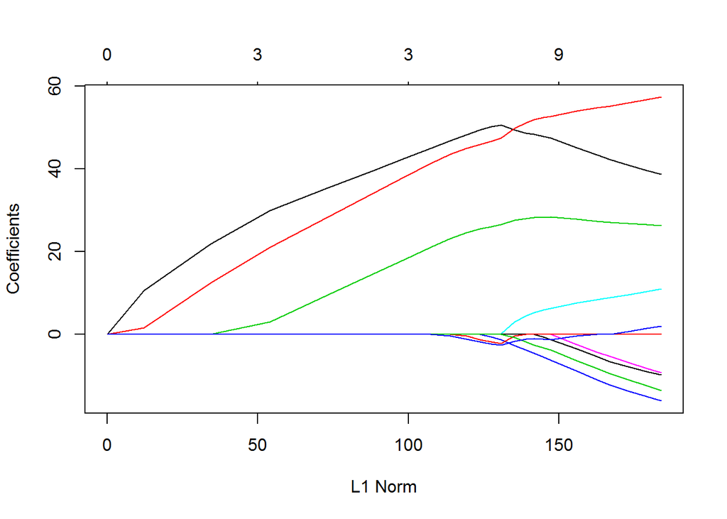

```r
set.seed(1)
grid = 10^seq(10, -2, length = 100)
train = sample(1:length(x), length(x) / 2)
test = -train
x = model.matrix(y~., data.frame(poly(x, 10)), y = y)[, -1]
y.test = y[test]
lasso.mod = glmnet(x[train, ], y[train], alpha = 1, lambda = grid)
plot(lasso.mod)
```

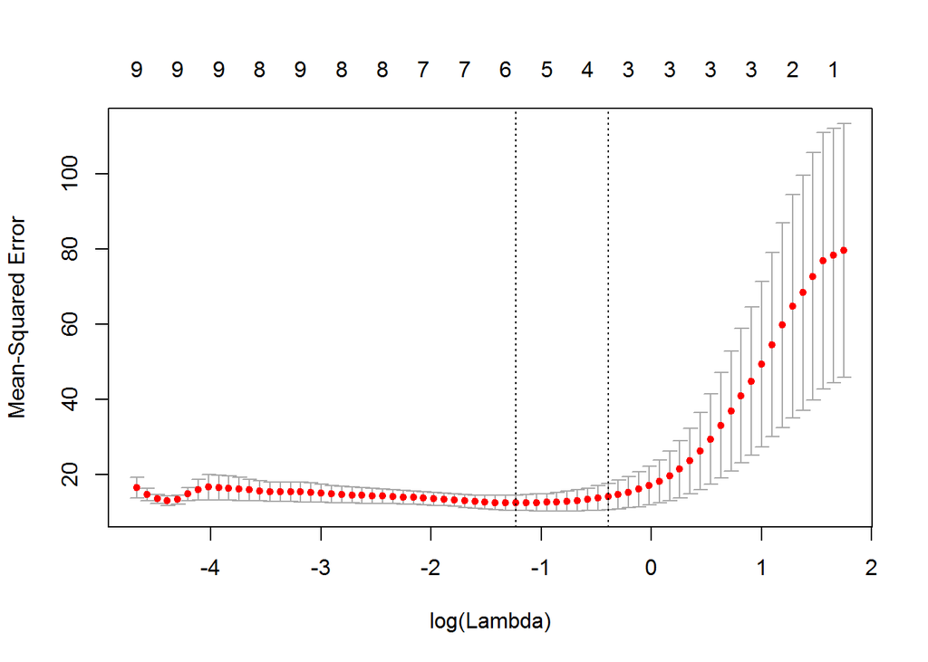

```r
cv.out = cv.glmnet(x[train, ], y[train], alpha = 1)
plot(cv.out)
```

```r
bestlam = cv.out$lambda.min
lasso.pred = predict(lasso.mod, s = bestlam, newx = x[test, ])
bestlam
```

```
## [1] 0.291909
```

```r
mean((lasso.pred - y.test)^2)
```

```
## [1] 10.04377
```

```r
out = glmnet(x, y, alpha = 1, lambda = grid)
lasso.coef = predict(out, type = "coefficients", s = bestlam)[1:11, ]
lasso.coef
```

```
## (Intercept)          X1          X2          X3          X4          X5
##    4.557712   45.192041   47.977736   26.967729   -1.220245    0.000000
##          X6          X7          X8          X9         X10
##    0.000000    0.000000    0.000000    0.000000   -1.296116
```

```r
# clean up
rm(list=setdiff(ls(), "bib"))
```

### Excercise 8f

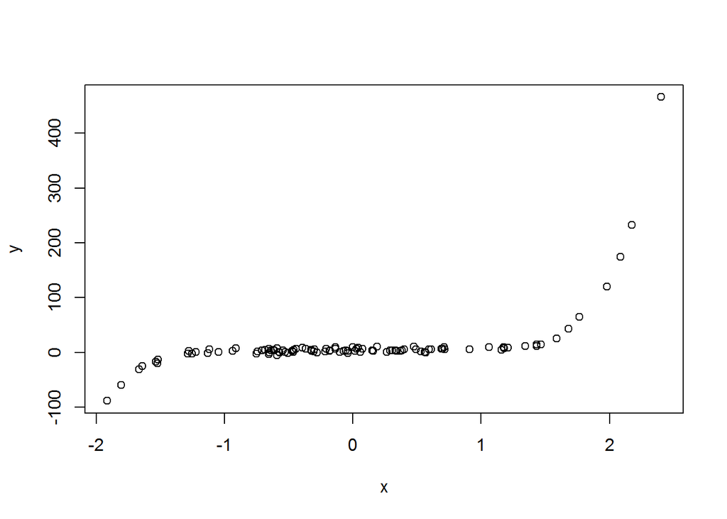

```r
x = rnorm(100)
y = 0.7 + 3.2 + x^7 + 3 * rnorm(100)
plot(x, y)
```

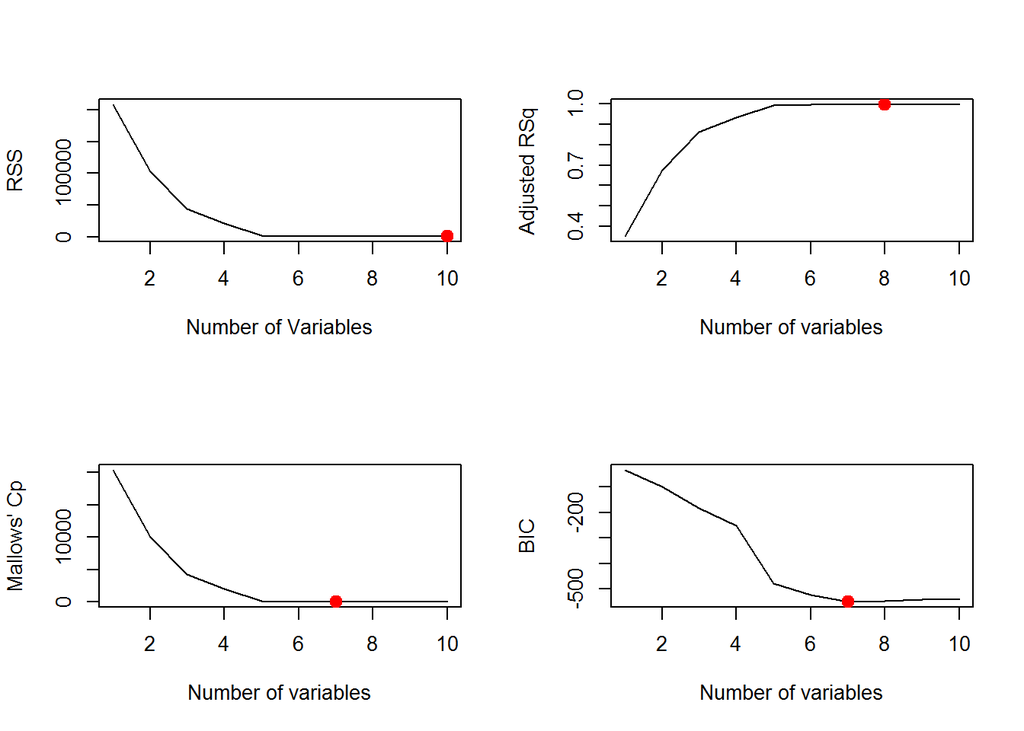

```r
regfit.full = regsubsets(y~., data = data.frame(poly(x, 10), y), nvmax = 10)
reg.summary = summary(regfit.full)
par(mfrow = c(2,2))
plot(reg.summary$rss, xlab = "Number of Variables", ylab = "RSS", type = "l")
points(which.min(reg.summary$rss), min(reg.summary$rss), col = "red", cex = 2, pch = 20)
plot(reg.summary$adjr2, xlab = "Number of variables", ylab = "Adjusted RSq", type = "l")
points(which.max(reg.summary$adjr2), max(reg.summary$adjr2), col = "red", cex = 2, pch = 20)
plot(reg.summary$cp, xlab = "Number of variables", ylab = "Mallows' Cp", type = "l")
points(which.min(reg.summary$cp), min(reg.summary$cp), col = "red", cex = 2, pch = 20)
plot(reg.summary$bic, xlab = "Number of variables", ylab = "BIC", type = "l")
points(which.min(reg.summary$bic), min(reg.summary$bic), col = "red", cex = 2, pch = 20)
```

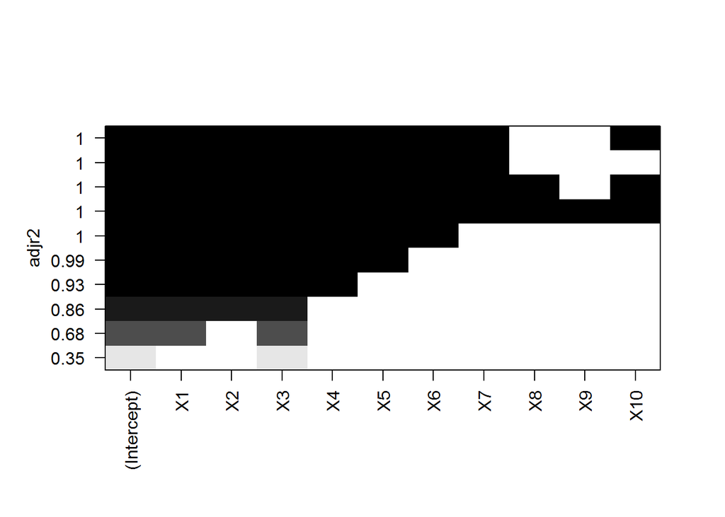

```r
# use built-in plot function
par(mfrow = c(1,1))
plot(regfit.full, scale = "adjr2")
```

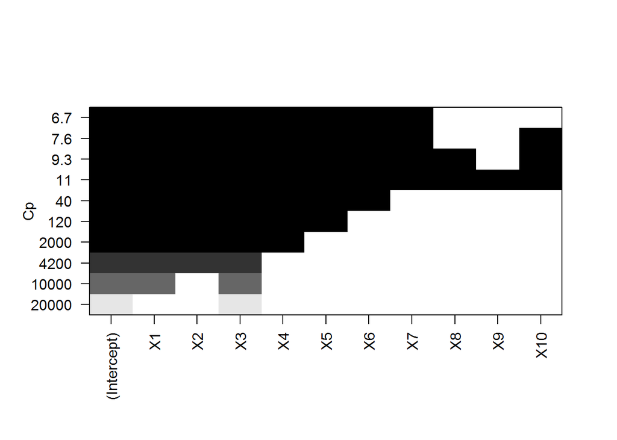

```r
plot(regfit.full, scale = "Cp")
```

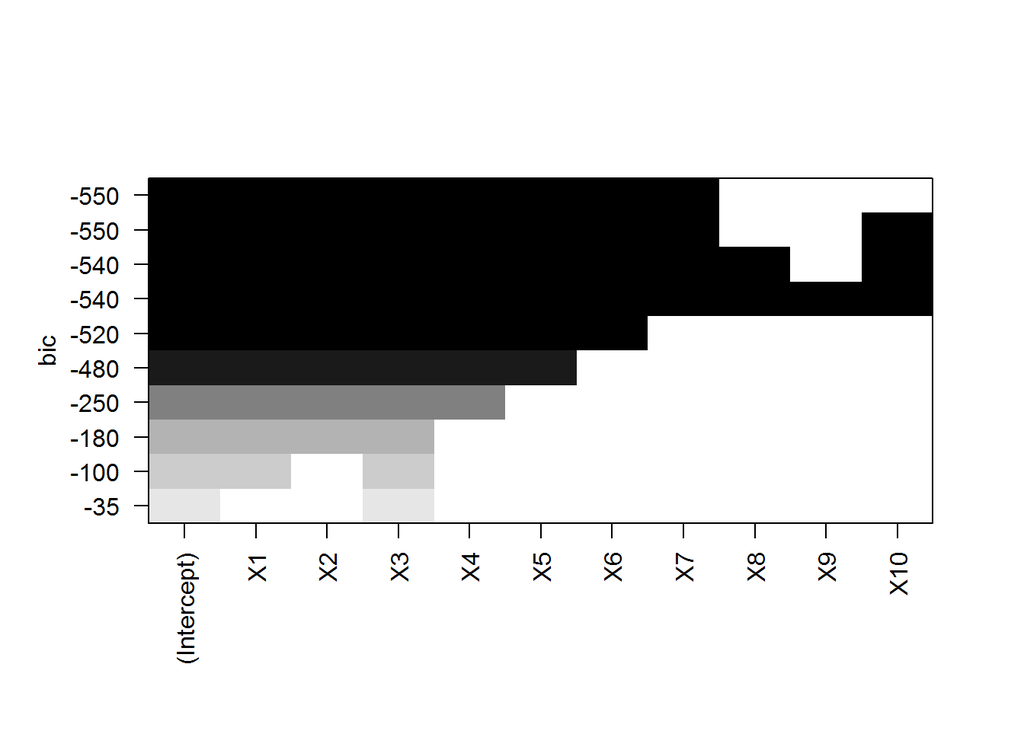

```r
plot(regfit.full, scale = "bic")
```

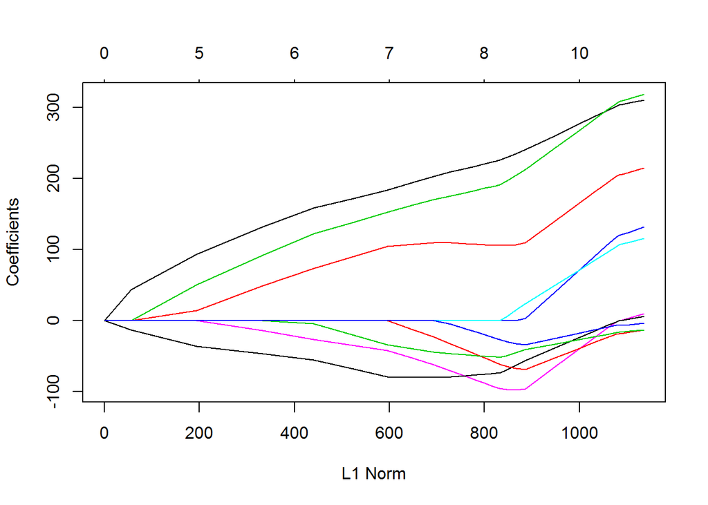

```r
library(glmnet)
set.seed(1)
grid = 10^seq(10, -2, length = 100)
train = sample(1:length(x), length(x) / 2)
test = -train
x = model.matrix(y~., data.frame(poly(x, 10)), y = y)[, -1]
y.test = y[test]
lasso.mod = glmnet(x[train, ], y[train], alpha = 1, lambda = grid)
plot(lasso.mod)
```

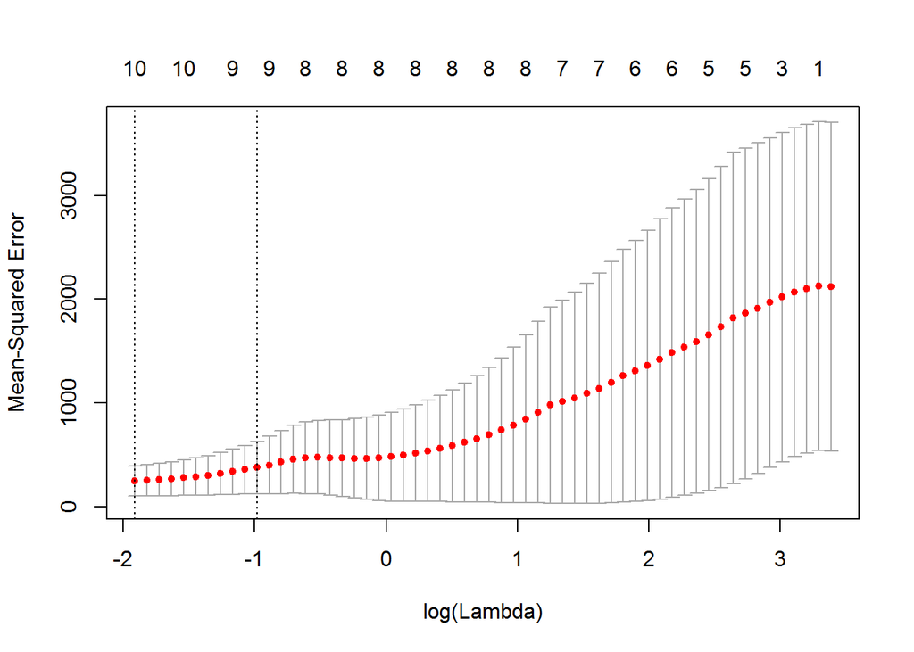

```r
cv.out = cv.glmnet(x[train, ], y[train], alpha = 1)
plot(cv.out)
```

```r
bestlam = cv.out$lambda.min
bestlam
```

```
## [1] 0.1474292
```

```r
out = glmnet(x, y, alpha = 1, lambda = grid)
lasso.coef = predict(out, type = "coefficients", s = bestlam)[1:8, ]
lasso.coef
```

```
## (Intercept)          X1          X2          X3          X4          X5
##    12.47875   323.89883   241.31004   338.77245   149.65528   135.64052
##          X6          X7
##    26.87355    17.33976
```

```r
coef(regfit.full, 7)
```

```
## (Intercept)          X1          X2          X3          X4          X5
##    12.47875   325.37310   242.78432   340.24673   151.12956   137.11480
##          X6          X7
##    28.34782    18.81404
```

```r
# clean up
rm(list=setdiff(ls(), "bib"))
```

Note that the results obtained from best subset selection method are similar to the ones obtained from lasso, both of which report that seven variables ($x$, $x^2$, …, $x^7$) should be chosen in order to ahieve the lowest test error.

### Excercise 9a

```r
library(ISLR)
attach(College)
set.seed(1)
train = sample(nrow(College), nrow(College) / 2)
test = -train
```

### Excercise 9b

```r
lm.fit = lm(Apps~., data = College, subset = train)
summary(lm.fit)
```

```
##
## Call:
## lm(formula = Apps ~ ., data = College, subset = train)
##
## Residuals:
##     Min      1Q  Median      3Q     Max
## -5276.1  -473.2   -63.9   351.9  6574.0
##
## Coefficients:
##               Estimate Std. Error t value Pr(>|t|)
## (Intercept)   78.15204  600.84427   0.130 0.896581
## PrivateYes  -757.22843  205.47577  -3.685 0.000263 ***
## Accept         1.67981    0.05196  32.329  < 2e-16 ***
## Enroll        -0.62380    0.27629  -2.258 0.024544 *
## Top10perc     67.45654    8.45231   7.981 1.84e-14 ***
## Top25perc    -22.37500    6.57093  -3.405 0.000734 ***
## F.Undergrad   -0.06126    0.05468  -1.120 0.263258
## P.Undergrad    0.04745    0.06248   0.760 0.448024
## Outstate      -0.09227    0.02889  -3.194 0.001524 **
## Room.Board     0.24513    0.07300   3.358 0.000867 ***
## Books          0.09086    0.36826   0.247 0.805254
## Personal       0.05886    0.09260   0.636 0.525455
## PhD           -8.89027    7.20890  -1.233 0.218271
## Terminal      -1.71947    8.22589  -0.209 0.834539
## S.F.Ratio     -5.75201   21.32871  -0.270 0.787554
## perc.alumni   -1.46681    6.28702  -0.233 0.815652
## Expend         0.03487    0.01928   1.808 0.071361 .
## Grad.Rate      7.57567    4.69602   1.613 0.107551
## ---
## Signif. codes:  0 '***' 0.001 '**' 0.01 '*' 0.05 '.' 0.1 ' ' 1
##
## Residual standard error: 1087 on 370 degrees of freedom
## Multiple R-squared:  0.9397, Adjusted R-squared:  0.9369
## F-statistic: 339.3 on 17 and 370 DF,  p-value: < 2.2e-16
```

```r
lm.pred = predict(lm.fit, College[test, ])
mean((lm.pred - Apps[test])^2)
```

```
## [1] 1108531
```

### Excercise 9c

```r
grid = 10^seq(10, -2, length = 100)
x = model.matrix(Apps~., College)[, -1]
y = Apps
```

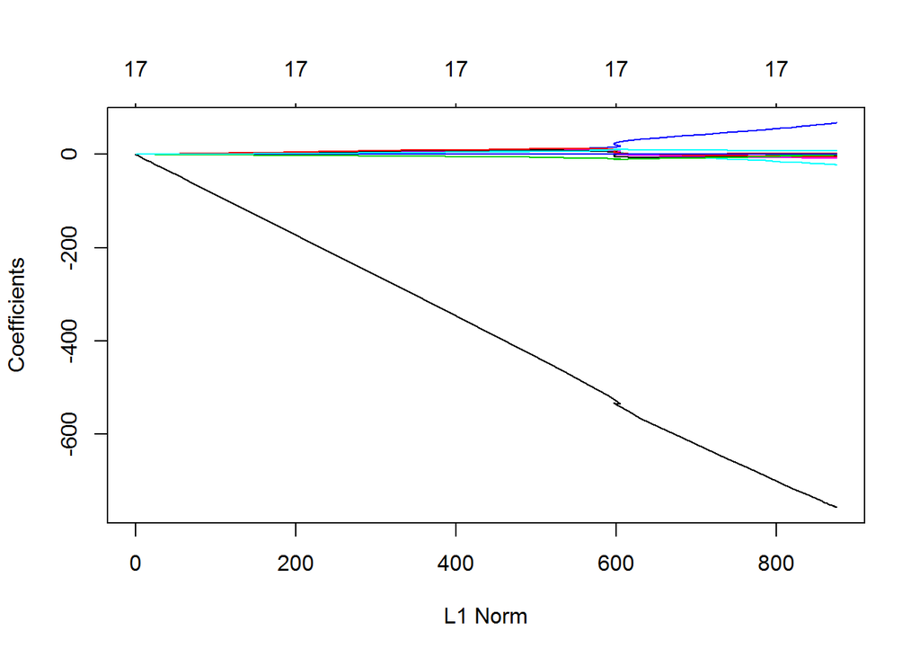

```r
ridge.mod = glmnet(x[train, ], y[train], alpha = 0, lambda = grid)
plot(ridge.mod)
```

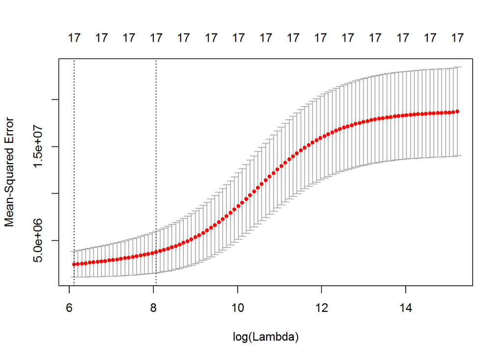

```r
cv.out = cv.glmnet(x[train, ], y[train], alpha = 0)
plot(cv.out)
```

```r
bestlam = cv.out$lambda.min
bestlam
```

```
## [1] 450.7435
```

```r
ridge.out = glmnet(x, y, alpha = 0)
ridge.pred = predict(ridge.mod, s = bestlam, newx = x[test, ])
mean((ridge.pred - y[test])^2)
```

```
## [1] 1036914
```

```r
ridge.coef = predict(ridge.out, type = "coefficients", s = bestlam)[1:(ncol(x)+1), ]
ridge.coef
```

```
##   (Intercept)    PrivateYes        Accept        Enroll     Top10perc
## -1.575123e+03 -5.312141e+02  9.443508e-01  5.084882e-01  2.395085e+01
##     Top25perc   F.Undergrad   P.Undergrad      Outstate    Room.Board
##  1.676068e+00  8.195201e-02  2.519290e-02 -1.804998e-02  2.008313e-01
##         Books      Personal           PhD      Terminal     S.F.Ratio
##  1.443091e-01 -9.669190e-03 -3.428226e+00 -4.551334e+00  1.260404e+01
##   perc.alumni        Expend     Grad.Rate
## -9.173762e+00  7.444322e-02  1.149378e+01
```

### Excercise 9d

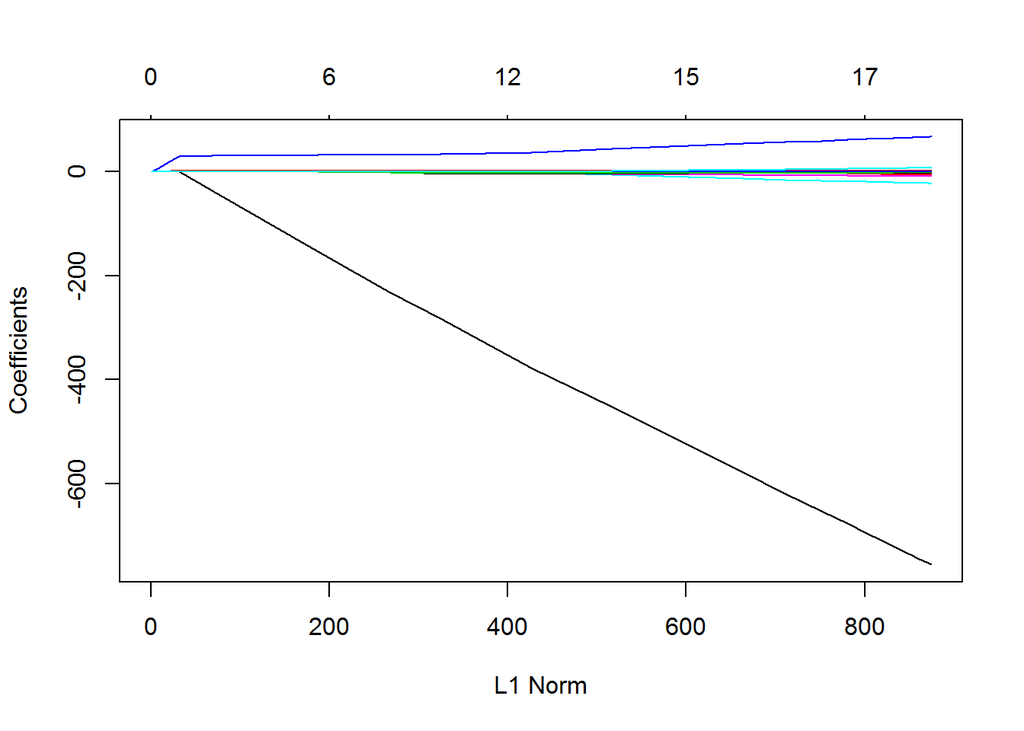

```r
lasso.mod = glmnet(x[train, ], y[train], alpha = 1, lambda = grid)
plot(lasso.mod)
```

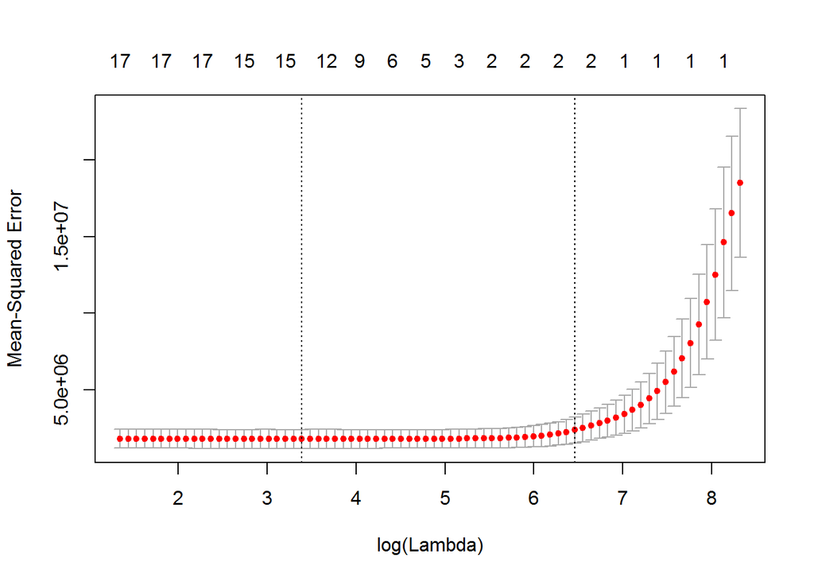

```r
cv.out = cv.glmnet(x[train, ], y[train], alpha = 1)
plot(cv.out)
```

```r
bestlam = cv.out$lambda.min
bestlam
```

```
## [1] 29.65591
```

```r
lasso.pred = predict(lasso.mod, s = bestlam, newx = x[test, ])
mean((lasso.pred - y[test])^2)
```

```
## [1] 1025428
```

```r
lasso.out = glmnet(x, y, alpha = 1)
lasso.coef = predict(lasso.out, type = "coefficients", s = bestlam)[1:(ncol(x)+1), ]
lasso.coef
```

```
##   (Intercept)    PrivateYes        Accept        Enroll     Top10perc
## -6.563963e+02 -3.848606e+02  1.407989e+00 -4.706185e-02  2.948577e+01
##     Top25perc   F.Undergrad   P.Undergrad      Outstate    Room.Board
##  0.000000e+00  0.000000e+00  6.028997e-03 -4.632275e-02  1.138675e-01
##         Books      Personal           PhD      Terminal     S.F.Ratio
##  0.000000e+00  0.000000e+00 -4.396271e+00 -3.201894e+00  1.739242e-01
##   perc.alumni        Expend     Grad.Rate
## -1.057849e+00  6.545444e-02  4.060286e+00
```

```r
nnzero(lasso.coef) - 1
```

```
## [1] 13
```

### Excercise 9e

```r
library(pls)
set.seed(1)
pcr.fit = pcr(Apps~., data = College, subset = train, scale = T, validation = "CV")
summary(pcr.fit)
```

```
## Data:    X dimension: 388 17
##  Y dimension: 388 1
## Fit method: svdpc
## Number of components considered: 17
##
## VALIDATION: RMSEP
## Cross-validated using 10 random segments.
##        (Intercept)  1 comps  2 comps  3 comps  4 comps  5 comps  6 comps
## CV            4335     4179     2364     2374     1996     1844     1845
## adjCV         4335     4182     2360     2374     1788     1831     1838
##        7 comps  8 comps  9 comps  10 comps  11 comps  12 comps  13 comps
## CV        1850     1863     1809      1809      1812      1815      1825
## adjCV     1844     1857     1801      1800      1804      1808      1817
##        14 comps  15 comps  16 comps  17 comps
## CV         1810      1823      1273      1281
## adjCV      1806      1789      1260      1268
##
## TRAINING: % variance explained
##       1 comps  2 comps  3 comps  4 comps  5 comps  6 comps  7 comps
## X      31.216    57.68    64.73    70.55    76.33    81.30    85.01
## Apps    6.976    71.47    71.58    83.32    83.44    83.45    83.46
##       8 comps  9 comps  10 comps  11 comps  12 comps  13 comps  14 comps
## X       88.40    91.16     93.36     95.38     96.94     97.96     98.76
## Apps    83.47    84.53     84.86     84.98     84.98     84.99     85.24
##       15 comps  16 comps  17 comps
## X        99.40     99.87    100.00
## Apps     90.87     93.93     93.97
```

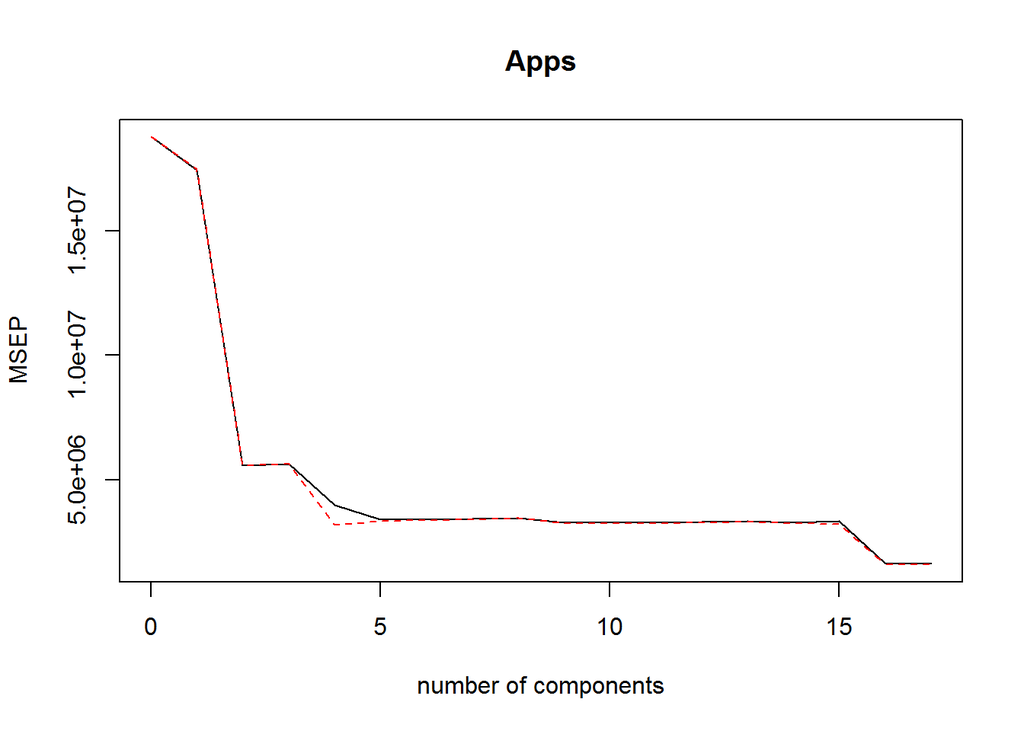

```r
validationplot(pcr.fit, val.type = "MSEP")
```

As we can see from above figure, the lowest cross-validation error occurs when $M = 16$ components are used. This is barely fewer than $M = 17$, which amounts to simply performing least squares.

```r
pcr.pred = predict(pcr.fit, x[test, ], ncomp = 16)
mean((pcr.pred - y[test])^2)
```

```
## [1] 1166897
```

### Excercise 9f

```r
pls.fit = plsr(Apps~., data = College, subset = train, scale = T, validation = "CV")
summary(pls.fit)
```

```
## Data:    X dimension: 388 17
##  Y dimension: 388 1
## Fit method: kernelpls
## Number of components considered: 17
##
## VALIDATION: RMSEP
## Cross-validated using 10 random segments.
##        (Intercept)  1 comps  2 comps  3 comps  4 comps  5 comps  6 comps
## CV            4335     2176     1888     1734     1605     1400     1311
## adjCV         4335     2171     1882     1724     1571     1373     1295
##        7 comps  8 comps  9 comps  10 comps  11 comps  12 comps  13 comps
## CV        1297     1287     1278      1278      1277      1281      1281
## adjCV     1281     1273     1265      1265      1264      1267      1268
##        14 comps  15 comps  16 comps  17 comps
## CV         1283      1284      1285      1285
## adjCV      1270      1271      1271      1272
##
## TRAINING: % variance explained
##       1 comps  2 comps  3 comps  4 comps  5 comps  6 comps  7 comps
## X       26.91    43.08    63.26    65.16    68.50    73.75    76.10
## Apps    76.64    83.93    87.14    91.90    93.49    93.85    93.91
##       8 comps  9 comps  10 comps  11 comps  12 comps  13 comps  14 comps
## X       79.03    81.76     85.41     89.03     91.38     93.31     95.43
## Apps    93.94    93.96     93.96     93.96     93.97     93.97     93.97
##       15 comps  16 comps  17 comps
## X        97.41     98.78    100.00
## Apps     93.97     93.97     93.97
```

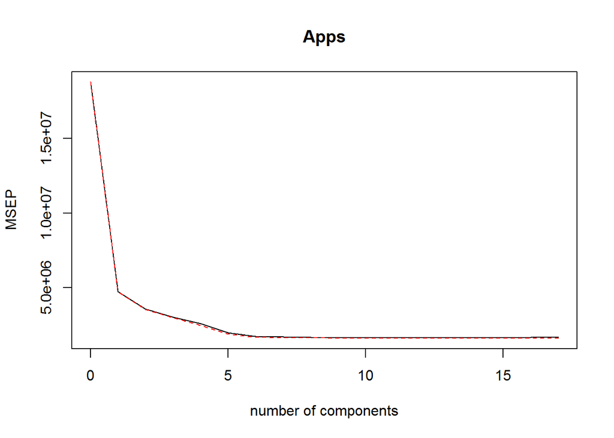

```r
validationplot(pls.fit, val.type = "MSEP")
```

As we can see from above figure, the lowest cross-validation error occurs when $M = 11$ components are used.

```r
pls.pred = predict(pls.fit, x[test, ], ncomp = 11)
mean((pls.pred - y[test])^2)
```

```
## [1] 1128934
```

### Excercise 9g

(Lasso regression has the lowest test error whereas the PCA has the highest)

, with barplot of the test R-Squared:

```r
test.avg = mean(Apps[test])
lm.test.r2 = 1 - mean((lm.pred - Apps[test])^2) / mean((Apps[test] - test.avg)^2)
ridge.test.r2 = 1 - mean((ridge.pred - Apps[test])^2) / mean((Apps[test] - test.avg)^2)
lasso.test.r2 = 1 - mean((lasso.pred - Apps[test])^2) / mean((Apps[test] - test.avg)^2)
pcr.test.r2 = 1 - mean((pcr.pred - Apps[test])^2) / mean((Apps[test] - test.avg)^2)
pls.test.r2 = 1 - mean((pls.pred - Apps[test])^2) / mean((Apps[test] - test.avg)^2)
c(lm.test.r2, ridge.test.r2, lasso.test.r2, pcr.test.r2, pls.test.r2)
```

```
## [1] 0.9010682 0.9074598 0.9084849 0.8958593 0.8992474
```

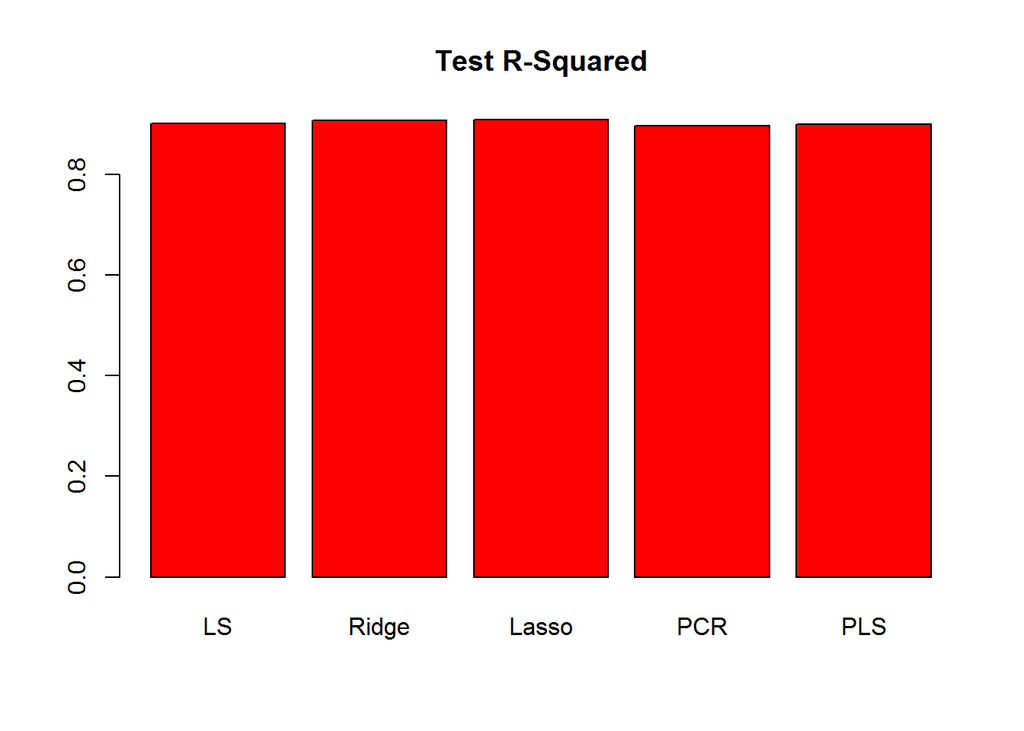

```r
barplot(c(lm.test.r2, ridge.test.r2, lasso.test.r2, pcr.test.r2, pls.test.r2), col = "red", names.arg = c("LS", "Ridge", "Lasso", "PCR", "PLS"), main = "Test R-Squared")
```

```r
#clean up
rm(list=setdiff(ls(), "bib"))
```

All five models have a R-squared value around 0.9, among which PCR’s and PLS’s values are slightly lower.

### Excercise 10a

```r
set.seed(1)
n = 1000
p = 20
colnames = c(); rownames = c()
for ( i in 1:p ) {
  colnames[i] = sprintf('X%d', i)
}
for ( i in 1:n ) {
  rownames[i] = sprintf('Observation_%d', i)
}
x = matrix(nrow = n, ncol = p, dimnames = list(rownames, colnames))
means = runif(p, -10, 10)
sds = runif(p, 0, 3)
for ( i in 1:p ) {
  x[, i] = rnorm(n, mean = means[i], sd = sds[i])
}
error = 3 * rnorm(n)
betas = runif(p, -5, 5)
betas[5:7] = 0; betas[11] = 0; betas[15:17] = 0 # number of non-zero coefficients = 13
betas
```

```
##  [1] -4.6188897  3.7969310  3.4126642  4.0979656  0.0000000  0.0000000
##  [7]  0.0000000 -1.7386517 -0.4075859 -2.1409501  0.0000000  0.3880612
## [13]  0.4098312  2.7516056  0.0000000  0.0000000  0.0000000 -0.7830795
## [19]  3.8018816 -0.3623938
```

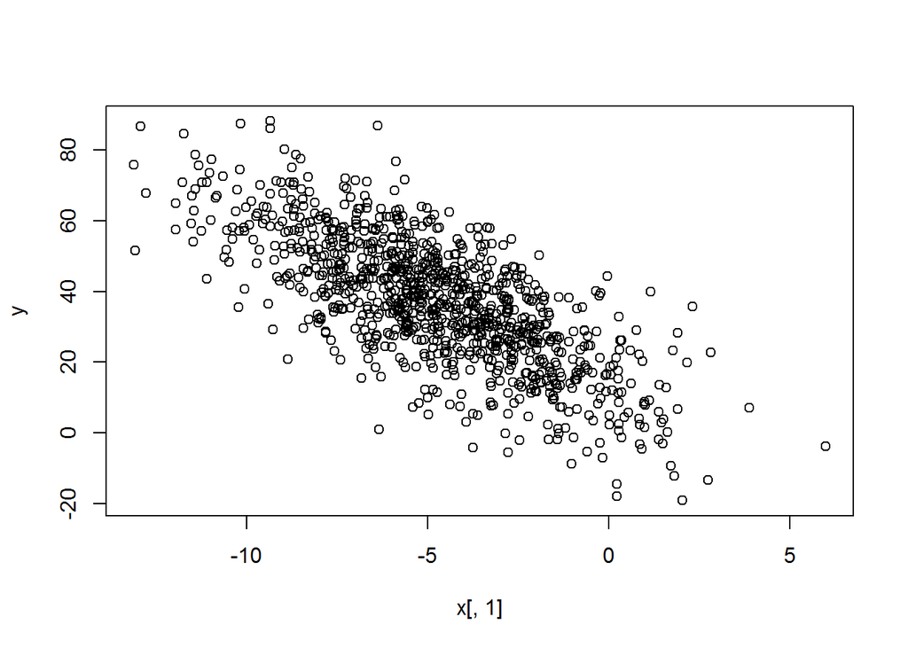

```r
y = x%*%betas + error
plot(x[,1], y)
```

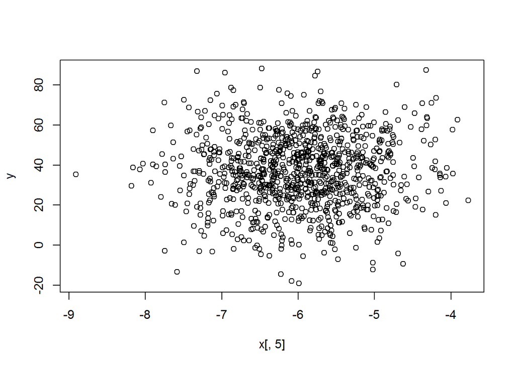

```r
plot(x[,5], y)
```

### Excercise 10b

```r
train = sample(n, n * 9 / 10)
test = -train
train.x = x[train, ]
test.x = x[test, ]
test.y = y[test]
```

### Excercise 10c

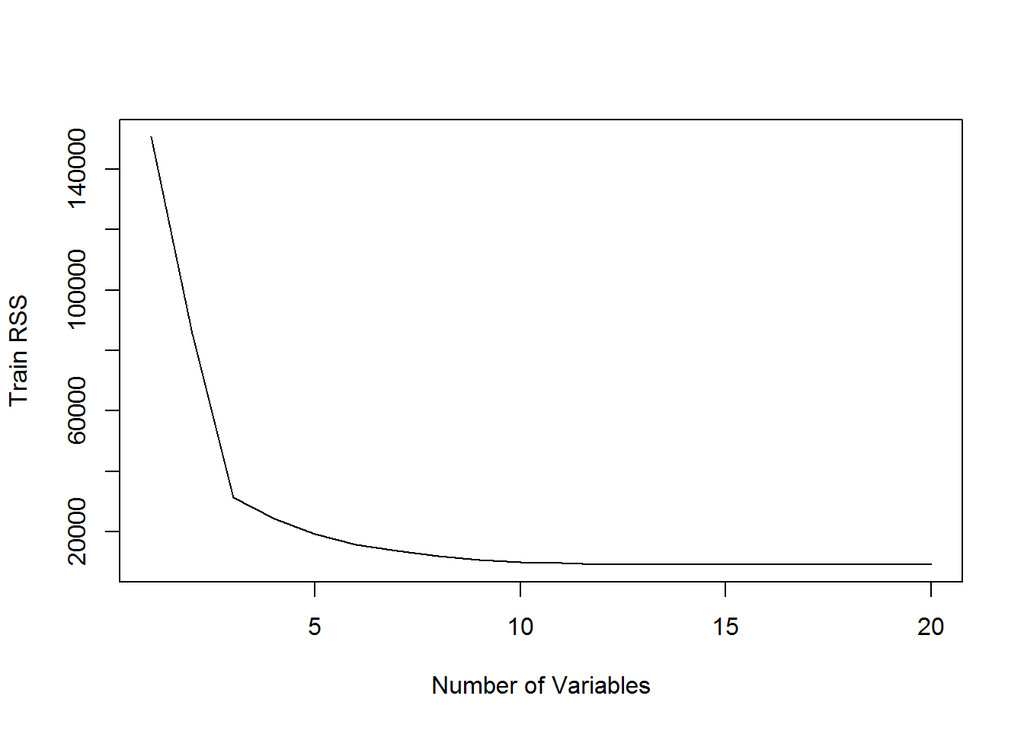

```r
library(leaps)
regfit.full = regsubsets(y~., data = data.frame(x, y), nvmax = p)
reg.summary = summary(regfit.full)
plot(reg.summary$rss, xlab = "Number of Variables", ylab = "Train RSS", type = "l")
```

### Excercise 10d

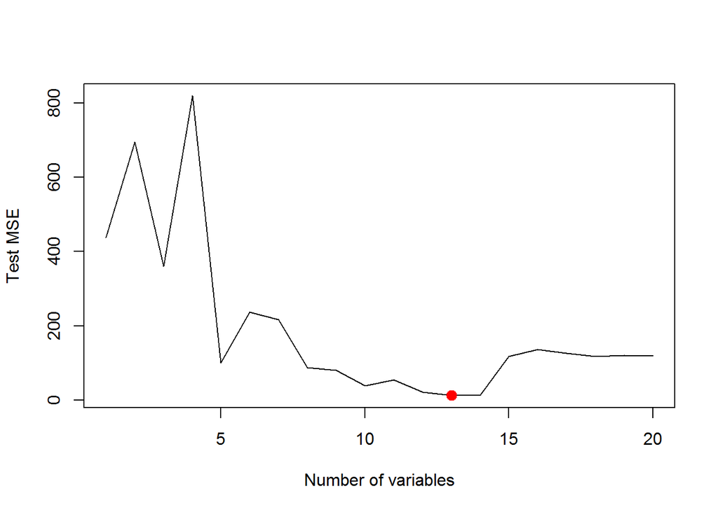

```r
test.rss = c()
for ( i in 1 : p ) {
  pred = as.matrix(test.x[, names(coef(regfit.full, i)[-1])]) %*% coef(regfit.full, i)[-1]
  test.rss[i] = mean((pred - test.y)^2)
}
plot(test.rss, type = "l", xlab = "Number of variables", ylab = "Test MSE")
points(which.min(test.rss), min(test.rss), col = "red", cex = 2, pch = 20)
```

### Excercise 10e

```r
which.min(test.rss)
```

```
## [1] 13
```

### Excercise 10f

```r
coef(regfit.full, which.min(test.rss))[-1]
```

```
##         X1         X2         X3         X4         X5         X8
## -4.6132871  3.8010938  3.4827985  3.5171487  0.2696702 -1.7311882
##         X9        X10        X12        X13        X14        X19
## -0.4154428 -2.2592743  0.4384599  0.4274868  2.5396586  3.8243842
##        X20
## -0.5127651
```

```r
names(betas) = colnames
betas
```

```
##         X1         X2         X3         X4         X5         X6
## -4.6188897  3.7969310  3.4126642  4.0979656  0.0000000  0.0000000
##         X7         X8         X9        X10        X11        X12
##  0.0000000 -1.7386517 -0.4075859 -2.1409501  0.0000000  0.3880612
##        X13        X14        X15        X16        X17        X18
##  0.4098312  2.7516056  0.0000000  0.0000000  0.0000000 -0.7830795
##        X19        X20
##  3.8018816 -0.3623938
```

In the true model, the number of non-zero coefficients is 13, which is the same with result obtained in *10(e)*. However, the true model has **5, 6, 7, 11, 15, 16, 17** -th coeffcients set to zero while in the model at which the test set MSE is minimized, **6, 7, 11, 15, 16, 17, 18** -th coefficient estiamtes are found to be zeros.

### Excercise 10g

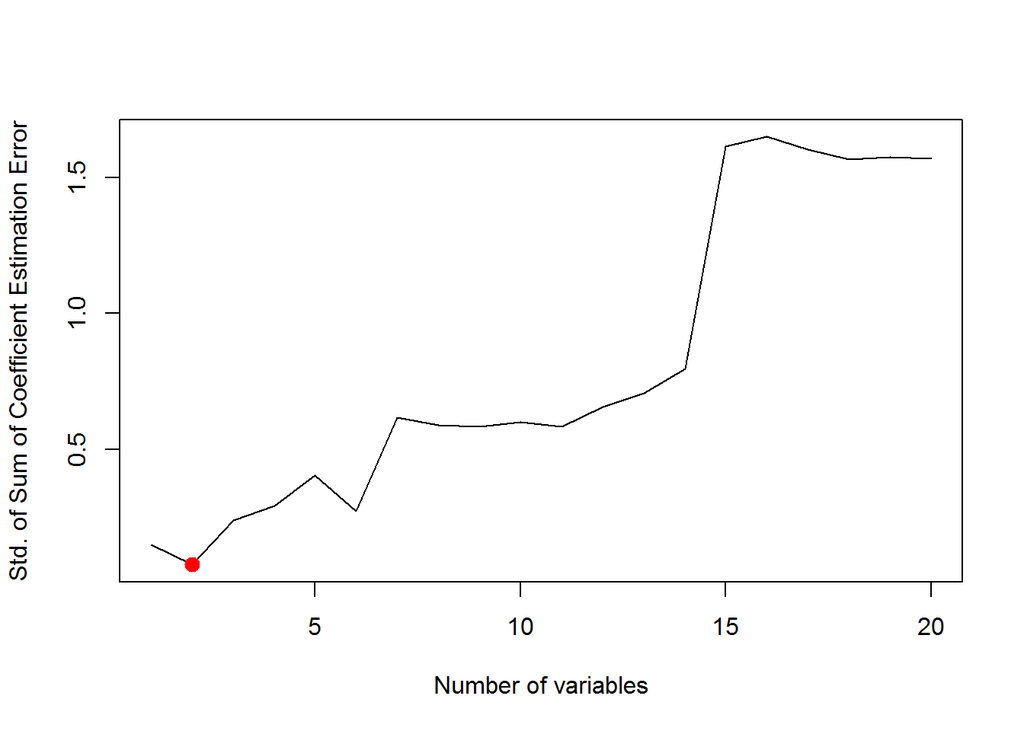

```r
sd_sum_error = c()
for ( i in 1 : p ) {
  sd_sum_error[i] = sqrt(sum((betas[names(coef(regfit.full, i)[-1])] - coef(regfit.full, i)[-1])^2))
}
plot(sd_sum_error, type = "l", xlab = "Number of variables", ylab = "Std. of Sum of Coefficient Estimation Error")
points(which.min(sd_sum_error), min(sd_sum_error), col = "red", cex = 2, pch = 20)
```

```r
which.min(sd_sum_error)
```

```
## [1] 2
```

```r
# clean up
rm(list=setdiff(ls(), "bib"))
```

When $p = 2$, the std. of sum of coefficient estimation error is lowest. The result is quite different from *10(d)* where 13 predictors were treated as the best selection.

Conclusively, a model with better fit of true coefficients doesn’t necessarily provide a lower test set error.

### Excercise 11a

Pre-processing steps:

```r
library(MASS)
library(leaps)
library(pls)
attach(Boston)
set.seed(1)
Boston = na.omit(Boston)
train = sample(nrow(Boston), nrow(Boston) / 2)
test = -train
```

Try best selection method with cross validation:

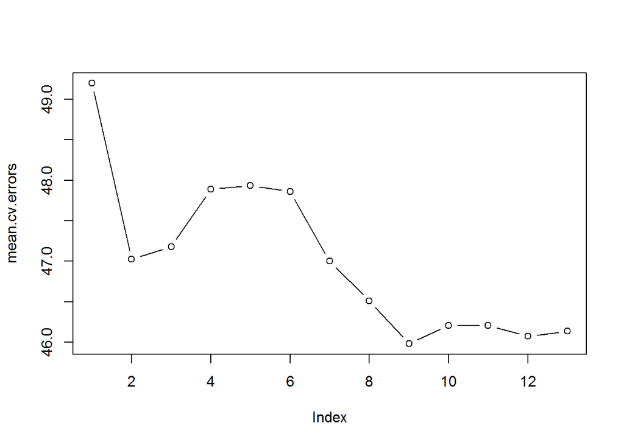

```r
predict.regsubsets = function(object, newdata, id, ...) {
  form = as.formula(object$call[[2]])
  mat = model.matrix(form, newdata)
  coefi = coef(object, id = id)
  xvars = names(coefi)
  return(mat[, xvars] %*% coefi)
}

k = 10; p = ncol(Boston) - 1
folds = sample(1:k, nrow(Boston), replace = T)
cv.errors = matrix(NA, k, p, dimnames = list(NULL, paste(1:p)))

for (j in 1:k) {
  best.fit = regsubsets(crim~., data = Boston[folds != j, ], nvmax = p)
  for (i in 1:p) {
    pred = predict(best.fit, Boston[folds==j, ], id = i)
    cv.errors[j, i] = mean((crim[folds==j] - pred)^2)
  }
}
mean.cv.errors = apply(cv.errors, 2, mean)
plot(mean.cv.errors, type = 'b')
```

```r
which.min(mean.cv.errors)
```

```
## 9
## 9
```

```r
# refit to calculate mean squared error
regfit.full = regsubsets(crim~., data = Boston[train, ], nvmax = p)
bestsubset.pred = predict(regfit.full, Boston[test, ], id = which.min(mean.cv.errors))
mean((bestsubset.pred - crim[test])^2)
```

```
## [1] 39.64198
```

```r
reg.best = regsubsets(crim~., data = Boston, nvmax = p)
bestsubset.coef = coef(reg.best, which.min(mean.cv.errors)) # according to result obtained in cross validation
bestsubset.coef
```

```
##   (Intercept)            zn         indus           nox           dis
##  19.124636156   0.042788127  -0.099385948 -10.466490364  -1.002597606
##           rad       ptratio         black         lstat          medv
##   0.539503547  -0.270835584  -0.008003761   0.117805932  -0.180593877
```

Some pre-processing steps for fitting other methods later:

```r
grid = 10^seq(10, -2, length = 100)
x = model.matrix(crim~., Boston)[, -1]
y = crim
```

Try ridge regression method:

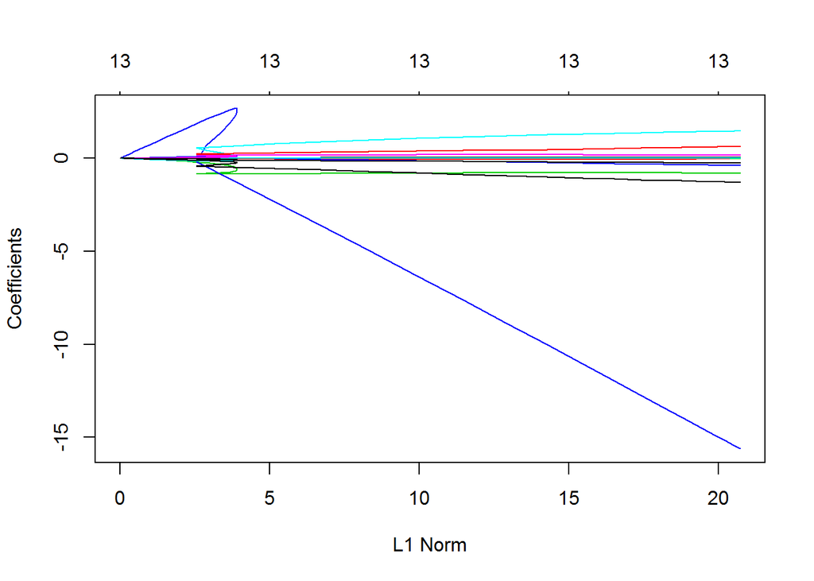

```r
ridge.mod = glmnet(x[train, ], y[train], alpha = 0, lambda = grid)
plot(ridge.mod)
```

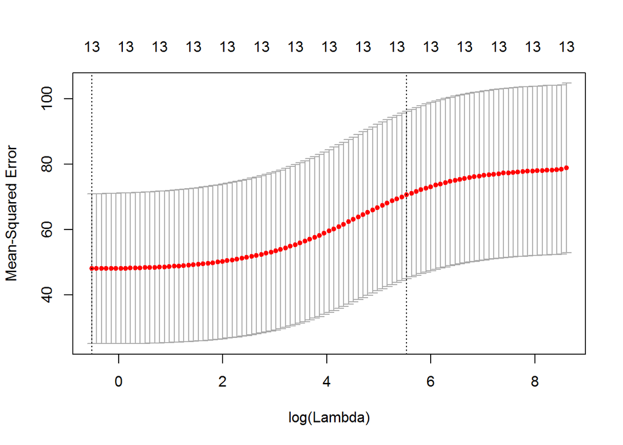

```r
cv.out = cv.glmnet(x[train, ], y[train], alpha = 0)
plot(cv.out)
```

```r
bestlam = cv.out$lambda.min
bestlam
```

```
## [1] 0.5982585
```

```r
ridge.out = glmnet(x, y, alpha = 0)
ridge.pred = predict(ridge.mod, s = bestlam, newx = x[test, ])
mean((ridge.pred - y[test])^2)
```

```
## [1] 38.36464
```

```r
ridge.coef = predict(ridge.out, type = "coefficients", s = bestlam)[1:(ncol(x)+1), ]
ridge.coef
```

```
##  (Intercept)           zn        indus         chas          nox
##  8.552102217  0.032255633 -0.081022623 -0.740357484 -5.051300376
##           rm          age          dis          rad          tax
##  0.326971132  0.002092933 -0.681039588  0.412977817  0.003737536
##      ptratio        black        lstat         medv
## -0.126371712 -0.008539983  0.142708910 -0.135821569
```

Try lasso regression method:

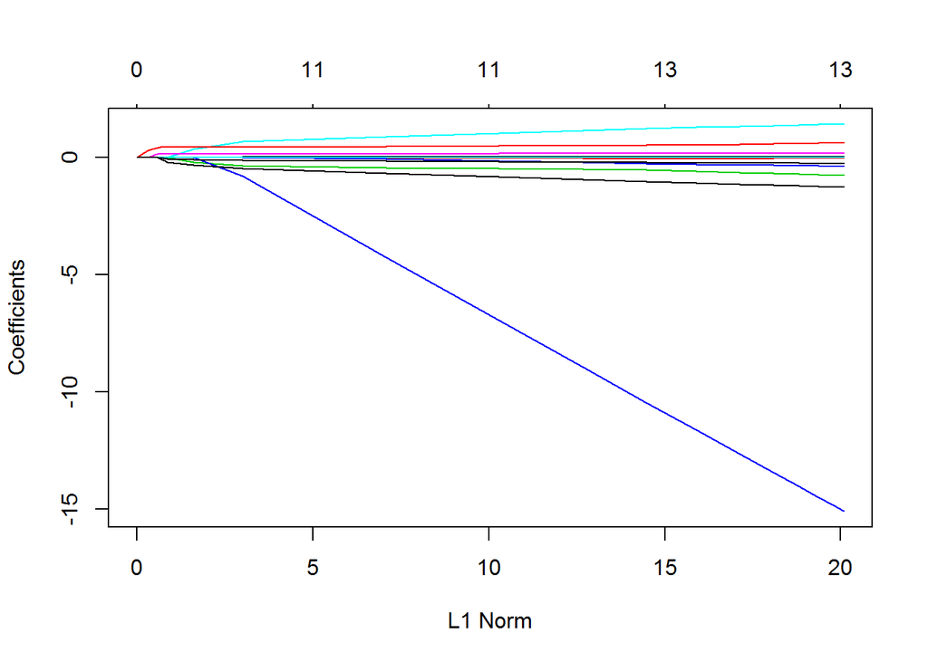

```r
lasso.mod = glmnet(x[train, ], y[train], alpha = 1, lambda = grid)
plot(lasso.mod)
```

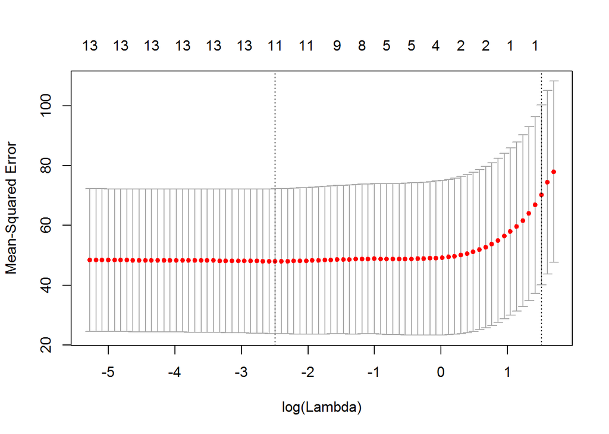

```r
cv.out = cv.glmnet(x[train, ], y[train], alpha = 1)
plot(cv.out)
```

```r
bestlam = cv.out$lambda.min
bestlam
```

```
## [1] 0.082852
```

```r
lasso.pred = predict(lasso.mod, s = bestlam, newx = x[test, ])
mean((lasso.pred - y[test])^2)
```

```
## [1] 38.37495
```

```r
lasso.out = glmnet(x, y, alpha = 1)
lasso.coef = predict(lasso.out, type = "coefficients", s = bestlam)[1:(ncol(x)+1), ]
lasso.coef
```

```
## (Intercept)          zn       indus        chas         nox          rm
## 10.49327942  0.03306034 -0.05836746 -0.53788430 -4.86675762  0.09886801
##         age         dis         rad         tax     ptratio       black
##  0.00000000 -0.66600513  0.50162998  0.00000000 -0.13551807 -0.00756184
##       lstat        medv
##  0.12086746 -0.13686346
```

```r
nnzero(lasso.coef) - 1
```

```
## [1] 11
```

Try pcr method:

```r
pcr.fit = pcr(crim~., data = Boston, subset = train, scale = T, validation = "CV")
summary(pcr.fit)
```

```
## Data:    X dimension: 253 13
##  Y dimension: 253 1
## Fit method: svdpc
## Number of components considered: 13
##
## VALIDATION: RMSEP
## Cross-validated using 10 random segments.
##        (Intercept)  1 comps  2 comps  3 comps  4 comps  5 comps  6 comps
## CV           8.892    7.552    7.534    7.224    7.183    7.219    7.280
## adjCV        8.892    7.544    7.526    7.213    7.161    7.209    7.264
##        7 comps  8 comps  9 comps  10 comps  11 comps  12 comps  13 comps
## CV       7.337    7.205    7.279     7.242     7.283     7.350     7.263
## adjCV    7.316    7.208    7.250     7.213     7.253     7.314     7.224
##
## TRAINING: % variance explained
##       1 comps  2 comps  3 comps  4 comps  5 comps  6 comps  7 comps
## X       49.04    60.72    69.75    76.49    83.02    88.40    91.73
## crim    30.39    30.93    36.63    37.31    37.35    37.98    38.85
##       8 comps  9 comps  10 comps  11 comps  12 comps  13 comps
## X       93.77    95.73     97.36     98.62     99.57    100.00
## crim    39.94    41.89     42.73     42.73     43.55     45.48
```